# Correlation test

# Partial correlation

The R package ppcor provides users with four functions: pcor(), pcor.test(), spcor(), and spcor.test().  
`pcor()` (spcor()) calculates the partial (semi-partial) correlations of all pairs of two random variables of a matrix or a data frame and provides the matrices of statistics and p-values of each pairwise partial (semi-partial) correlation. `pcor.test()` ( spcor.test()) computes the pairwise partial (semipartial) correlation coefficient of a pair of two random variables given one or more random variables.

```r
#install.packages("ppcor")
library(ppcor)
```

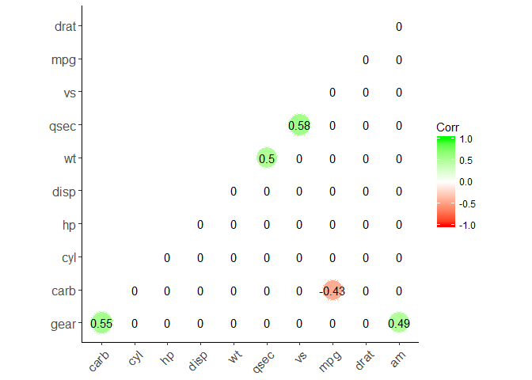

```r
partial.corr <- pcor(x=mtcars, method="spearman")
#Results interpretation: ?pcor()

library(ggcorrplot)
ggcorrplot(partial.corr$estimate,
           method = "circle",  #"square" (default), "circle"
           type = "lower", # "full" (default), "lower" or "upper" display.
           hc.order = TRUE, #logical value. If TRUE, correlation matrix will be hc.ordered using hclust function.
           outline.col = "white", #the outline color of square or circle. Default "gray"
           ggtheme = ggplot2::theme_classic, #Change theme
           colors = c("red", "white", "green"), #Change colors
           lab = TRUE, #Add correlation coefficients
           sig.level=0.05, #set significant level
           p.mat = partial.corr$p.value, #Add correlation significance level
           insig = "blank" #Leave blank on no significant coefficient
           )
```

```r
#Warning: "Error in solve.default(cvx) : system is computationally singular: reciprocal condition number = 3.60323e-19", means "more variables than observations, in which case your design matrix is probably not full rank."
```

# References

[Correlation Test Between Two Variables in R](http://www.sthda.com/english/wiki/correlation-test-between-two-variables-in-r) [correlation formula](http://www.sthda.com/english/wiki/correlation-formula) [Correlation coefficient](http://www.sthda.com/english/wiki/correlation-coefficient) [Correlation coefficient calculator](http://www.sthda.com/english/wiki/correlation-coefficient-calculator) [Correlation matrix online software: Analysis and visualization](http://www.sthda.com/english/rsthda/correlation-matrix.php) [Elegant correlation table using xtable R package](http://www.sthda.com/english/wiki/elegant-correlation-table-using-xtable-r-package) [Correlation matrix : An R function to do all you need](http://www.sthda.com/english/wiki/correlation-matrix-an-r-function-to-do-all-you-need) [Correlation matrix: analyze, format and visualize](http://www.sthda.com/english/wiki/correlation-matrix-a-quick-start-guide-to-analyze-format-and-visualize-a-correlation-matrix-using-r-software) [ggplot2: Quick correlation matrix heatmap](http://www.sthda.com/english/wiki/ggplot2-quick-correlation-matrix-heatmap-r-software-and-data-visualization) [corrplot: Visualize correlation matrix](http://www.sthda.com/english/wiki/visualize-correlation-matrix-using-correlogram) [ggcorrplot: Visualization of a correlation matrix using ggplot2](http://www.sthda.com/english/wiki/ggcorrplot-visualization-of-a-correlation-matrix-using-ggplot2) [ppcor](https://cran.r-project.org/web/packages/ppcor/ppcor.pdf)